# Lab 5: Wide and Deep Network Architures

By Yifan Ding

# Preparation (40 Points Total)

## Business Understanding (used for metric argument)

Among the questions that can be explored using this dataset include: (1) “What (if any) is the white advantage given relative ratings and opening position?”, (2) “What are the best moves after a specific opening that lead to victory?”, (3) “Will this position result in a draw?”, and (4) “Who is going to win after the opening?” The white advantage question can be answered with data visualization. The best moves question is best answered with a chess engine such as Stockfish. The draw question is a probability question.

For this assignment, our question is “Who is most likely to win the game after 5 moves (10 half-moves) of a chess game?”

The prediction task is to predict the winner of a chess match while it is on-going. The model will be given the metadata of the match, the type of opening, and the first ten half moves of a chess game. The most obvious use for our data is by gambling websites to set true odds of matches or, alternatively, by individual gamblers to find attractive bets. The “while on-going” is because many websites are starting to implement live gambling. If this innovation comes to chess, than similar models will become necessary by gambling websites to update the true odds of who will win. While the data was compiled on Lichess.com with its own rating system, our model could on any game where the ratings of the players come from the FIDE (International Chess Federation), USCF (United States Chess Federation), and the popular website Chess.Com as these ratings are highly correlated. We know this because there even exists a rating comparison site, https://chessgoals.com/rating-comparison/, that can be used to convert between Lichess.com, Chess.com, FIDE, and USCF chess ratings. Thus, if a gambler knows the maximum time of the match, a viable chess rating for black or white, and the opening ten moves—he should be able to predict who will win. If a real-time betting site exists, he will have an idea of whether to make a bet. Or alternatively, the gambling website will be able to update the true odds so that the website can make money. If used, our model would be deployed for real-time analysis.

Our model would be helpful if knowing the opening ten moves, which player is white, and the time increment (how much time was allowed on the chess clock) provides useful information beyond just the rating of the player. Using just the rating, there is a formula which predicts who should win the match. From Wikipedia, the formula for an ELO rating system is as follows:

$$ P_{white} + \frac{1}{2}P_{draw}= \frac{1}{1+10^{\frac{black_{rating}-white_{rating}}{400}}} $$

Where $P_{white}$ is the probability that white will win, $P_{draw}$ is the probability of a draw, $black_{rating}$ is the rating of black under FIDE, and $white_{rating}$ is the rating of white under FIDE. Note that the rating formula is only taken for FIDE, as FIDE uses the ELO rating formula. The rating system for Lichess.com uses the Glicko-2 rating system. As mentioned above, however, these rating systems are highly correlated and thus can be converted between one another with a technique like linear regression.

For example, if is there a 200 point difference between two players, the higher rated player is expected to win approximately 75% of the available points ($P_{win}$ + 1/2 $P_{draw}$). Note that this formula does not know the draw probability and does not attempt to find it. However, we can estimate the $P_{draw}$ as the sample $P_{draw}$ of 4.74%. Plugging $P_{draw}$ into the equation we can write a formula that predicts the probability of a white win, probability of a black win, and probability of a draw based only on the rating.

$$ P_{white} = \frac{1}{1+10^{\frac{black_{rating}-white_{rating}}{400}}}-0.024 $$

$$ P_{black} = \frac{1}{1+10^{\frac{white_{rating}-black_{rating}}{400}}}-0.024 $$

$$ P_{draw} = 0.048 $$

Using these three formulas, we can create a classifier that predicts $P_{white}$ based on which probability is larger. Our model is trying to be better than this simple classifier.

We can write a more sophisticated predictor for $P_{draw}$ as $P_{draw}$ depends on both the average ratings of the player and the absolute value of the difference of the ratings. The average rating of the player is positively correlated with $P_{draw}$, while the absolute value of the difference is negatively correlated with $P_{draw}$. The following graph is from chess-db.com which is a database which includes over eight million chess games. From the graph below, you can see that the slope is negative($P_{draw}$ decreases as the difference increases) and that higher lines have higher average ratings(better players have a higher $P_{draw}$ overall.

[figure not shown]

https://chess-db.com/public/research/draw_rate.html

Last, we see that Pdraw is much higher overall than it is for lichess.com. This can probably be explained by how serious the players are taking the game—lichess.com probably has many people who are playing casually—which will result in a lower draw rate than a draw rate under different circumstances.

## Citations for Business Understanding

En.wikipedia.org. (2019). Chess notation. [online] Available at: https://en.wikipedia.org/wiki/Chess_notation [Accessed 14 Sep. 2019].

En.wikipedia.org. (2019). Chess rating system. [online] Available at: https://en.wikipedia.org/wiki/Chess_rating_system [Accessed 14 Sep. 2019].

Chess-db.com. (2019). Draw Rate in Chess Tournaments. [online] Available at: https://chess-db.com/public/research/draw_rate.html [Accessed 14 Sep. 2019].

En.wikipedia.org. (2019). Elo rating system. [online] Available at: https://en.wikipedia.org/wiki/Elo_rating_system [Accessed 14 Sep. 2019].

En.wikipedia.org. (2019). First-move advantage in chess. [online] Available at: https://en.wikipedia.org/wiki/First-move_advantage_in_chess [Accessed 14 Sep. 2019].

En.wikipedia.org. (2019). List of chess openings. [online] Available at: https://en.wikipedia.org/wiki/List_of_chess_openings [Accessed 14 Sep. 2019].

# Metric Selection (10 Points Total)

From the business case, we are creating a model for chess prediction that will assign a probability to the white player winning, black player winning, and probability of draw. What we really want to do is compare the accuracy of the model performance. For example, if the model says white will win 70% of the time in a certain scenario, we want to evaluate whether white actually does win 70% of the time. Thus, accuracy and f1 score do not make a lot of sense for this business case. Instead, we want to use either Brier score or Log-Loss. Essentially, the brier score is the output of the loss function for mean squared error

$$Brier Score = \frac{1}{N}*\sum_{i = 1}^{N}(f_{i}-\sigma _{i})^{2}$$

Where $$F_{i}$$ is predicted probability white won and $$\sigma_{i}$$ is 1 if white won and zero otherwise.

The Brier score is a cost function there a lower score is better. Essentially, it sums the square error of the forecast and whether or not that event occurred. Thus, to be perfect, it must declare one event will happen 100% of the time and be correct. However, because you square this (ft – sigmat) quantity, you are penalized if you are too certain as the square increases non-linearly for larger numbers.

The other common option is to use the Log-Loss score. The log=loss score is also called cross-entropy or logistic loss or logarithmic loss. This is similar to the Brier score except that the penalty is the logarithmic instead of squared. This also means that the result is not bounded—if the model predicts zero for an event and it happens, then the model will severly punish the model. In practice, the log loss and brier score will perform simiarly for our application-- so we will choose the Brier score.

# Citation

Brownlee, J. (2019). A Gentle Introduction to Probability Scoring Methods in Python. [online] Machine Learning Mastery. Available at: https://machinelearningmastery.com/how-to-score-probability-predictions-in-python/ [Accessed 16 Nov. 2019].

Dinga, R., Penninx, B., Veltman, D., Schmaal, L. and Marquand, A. (2019). Beyond accuracy: Measures for assessing machine learning models, pitfalls and guidelines.

En.wikipedia.org. (2019). Brier score. [online] Available at: https://en.wikipedia.org/wiki/Brier_score [Accessed 16 Nov. 2019].

En.wikipedia.org. (2019). Cross entropy. [online] Available at: https://en.wikipedia.org/wiki/Cross_entropy [Accessed 16 Nov. 2019].

# Data Preparation (10 Points Total)

## Define Data Types

### Reading in File

```python
# Reading Data from CSV with Pandas
from sklearn.linear_model import LinearRegression
import matplotlib.pyplot as plt
import matplotlib.pylab as plt1
from sklearn.manifold import TSNE
import seaborn as sns
import missingno as mn
import pandas as pd
import numpy as np
import math

def get_csv_from_file(file):
    '''
    Input: file name
    Output: csv of file
    '''
    with open(file) as f:
       csv1 = pd.read_csv(f)
    return csv1

# original dataset is from https://www.kaggle.com/datasnaek/chess
file = '/Users/KobeInc/Desktop/games.csv'
chess_original = get_csv_from_file(file)

chess_regression = pd.read_csv(file)
chess_cat = pd.read_csv(file)
chess_onehot = pd.read_csv(file) # we will add one-hot encoding to a dataframe used for TSNE

def remove_feature(dataframe, feature):
    '''
    Input: dataframe, feature to remove
    Output: dataframe without feature
    '''
    if feature in dataframe:
        dataframe = dataframe.drop(feature, axis = 1)
    return dataframe

def select_feature(df, name):
    '''
    Input: dataframe, name of feaure, data
    Ouput: dataframe with feature selected
    '''
    feature = df[name]
    return feature

def add_feature(df, name, data):
    '''
    Input: dataframe, name of feaure, data
    Ouput: dataframe with feature added
    '''
    df[name] = data
    return df

def one_hot_encode(df, name, cat_columns):
    '''
    Input: dataframe, name of feaure, categories of the column
    Output: dataframe with one hot encoded feature added
    '''
    if name in df:
        name = pd.get_dummies(df[name],prefix_sep='_',columns=cat_columns)
    return name

#Preview the first five lines of the data
chess_original.head()
```

|  | id | rated | created_at | last_move_at | turns | victory_status | winner | increment_code | white_id | white_rating | black_id | black_rating | moves | opening_eco | opening_name | opening_ply |
| --- | --- | --- | --- | --- | --- | --- | --- | --- | --- | --- | --- | --- | --- | --- | --- | --- |
| 0 | TZJHLljE | False | 1.504210e+12 | 1.504210e+12 | 13 | outoftime | white | 15+2 | bourgris | 1500 | a-00 | 1191 | d4 d5 c4 c6 cxd5 e6 dxe6 fxe6 Nf3 Bb4+ Nc3 Ba5... | D10 | Slav Defense: Exchange Variation | 5 |
| 1 | l1NXvwaE | True | 1.504130e+12 | 1.504130e+12 | 16 | resign | black | 5+10 | a-00 | 1322 | skinnerua | 1261 | d4 Nc6 e4 e5 f4 f6 dxe5 fxe5 fxe5 Nxe5 Qd4 Nc6... | B00 | Nimzowitsch Defense: Kennedy Variation | 4 |
| 2 | mIICvQHh | True | 1.504130e+12 | 1.504130e+12 | 61 | mate | white | 5+10 | ischia | 1496 | a-00 | 1500 | e4 e5 d3 d6 Be3 c6 Be2 b5 Nd2 a5 a4 c5 axb5 Nc... | C20 | King's Pawn Game: Leonardis Variation | 3 |
| 3 | kWKvrqYL | True | 1.504110e+12 | 1.504110e+12 | 61 | mate | white | 20+0 | daniamurashov | 1439 | adivanov2009 | 1454 | d4 d5 Nf3 Bf5 Nc3 Nf6 Bf4 Ng4 e3 Nc6 Be2 Qd7 O... | D02 | Queen's Pawn Game: Zukertort Variation | 3 |
| 4 | 9tXo1AUZ | True | 1.504030e+12 | 1.504030e+12 | 95 | mate | white | 30+3 | nik221107 | 1523 | adivanov2009 | 1469 | e4 e5 Nf3 d6 d4 Nc6 d5 Nb4 a3 Na6 Nc3 Be7 b4 N... | C41 | Philidor Defense | 5 |

## Remove Unnecessary Variables

```python
# Print Original data types
print(chess_original.info())
```

```
<class 'pandas.core.frame.DataFrame'>
RangeIndex: 20058 entries, 0 to 20057
Data columns (total 16 columns):
id                20058 non-null object
rated             20058 non-null bool
created_at        20058 non-null float64
last_move_at      20058 non-null float64
turns             20058 non-null int64
victory_status    20058 non-null object
winner            20058 non-null object
increment_code    20058 non-null object
white_id          20058 non-null object
white_rating      20058 non-null int64
black_id          20058 non-null object
black_rating      20058 non-null int64
moves             20058 non-null object
opening_eco       20058 non-null object
opening_name      20058 non-null object
opening_ply       20058 non-null int64
dtypes: bool(1), float64(2), int64(4), object(9)
memory usage: 2.3+ MB
None
```

```python
#We will get rid of id(id of game,white id and black id) as these names are not necessary for prediction
chess_regression = remove_feature(chess_regression, 'id')
chess_regression = remove_feature(chess_regression, 'white_id')
chess_regression = remove_feature(chess_regression, 'black_id')

#For 'opening_eco' and 'opening_name', We will only use 'opening_eco' and drop opening_name
chess_regression = remove_feature(chess_regression, 'opening_name')

#Created at and last move at are not known at time of prediction part-way through the game
chess_regression = remove_feature(chess_regression, 'created_at')
chess_regression = remove_feature(chess_regression, 'last_move_at')

#victory_status not known at time of prediction
chess_regression = remove_feature(chess_regression, 'victory_status')
```

```python
#We will get rid of id(id of game,white id and black id) as these names are not necessary for prediction
chess_cat = remove_feature(chess_cat, 'id')
chess_cat = remove_feature(chess_cat, 'white_id')
chess_cat = remove_feature(chess_cat, 'black_id')

#For 'opening_eco' and 'opening_name', We will only use 'opening_eco' and drop opening_name
chess_cat = remove_feature(chess_cat, 'opening_name')

#Created at and last move at are not known at time of prediction part-way through the game
chess_cat = remove_feature(chess_cat, 'created_at')
chess_cat = remove_feature(chess_cat, 'last_move_at')

#victory_status not known at time of prediction
chess_cat = remove_feature(chess_cat, 'victory_status')
```

```python
#We will get rid of id(id of game,white id and black id) as these names are not necessary for prediction
chess_onehot = remove_feature(chess_onehot, 'id')
chess_onehot = remove_feature(chess_onehot, 'white_id')
chess_onehot = remove_feature(chess_onehot, 'black_id')#chess_cat.head()  #verify features have been removed

#For opening_eco' and 'opening_name', We will only use 'opening_eco' and drop opening_name
chess_onehot = remove_feature(chess_onehot, 'opening_name')

#Created at and last move at are not known at time of prediction part-way through the game
chess_onehot = remove_feature(chess_onehot, 'created_at')
chess_onehot = remove_feature(chess_onehot, 'last_move_at')
#chess_onehot.head()  #verify features have been removed

#victory_status not known at time of prediction
chess_onehot = remove_feature(chess_onehot, 'victory_status')
```

```python
# Verify variables have been removed from working copy
print(chess_regression.info())
```

```
<class 'pandas.core.frame.DataFrame'>
RangeIndex: 20058 entries, 0 to 20057
Data columns (total 9 columns):
rated             20058 non-null bool
turns             20058 non-null int64
winner            20058 non-null object
increment_code    20058 non-null object
white_rating      20058 non-null int64
black_rating      20058 non-null int64
moves             20058 non-null object
opening_eco       20058 non-null object
opening_ply       20058 non-null int64
dtypes: bool(1), int64(4), object(4)
memory usage: 1.2+ MB
None
```

```python
#print(chess_onehot.info())
```

### Rated Variable Type

Rated variable: Whether the game result will affect the players' rating score. For not rated games, the result will not be recorded. The 'Rated' variable matters since the player will be more motivated to win the game. Our hypothesis is that rated games are treated seriously--so there will be fewer upsets.

```python
#From above 'rated' is a boolean. For True is a rated game while False is non-rated.
print('Rated should be a boolean: ' + str(type(chess_regression.rated[0])))

# Rated should be one-hot encoded for chess_onehot
rated_dummy = one_hot_encode(chess_regression, 'rated' , [True, False])
chess_regression = pd.concat([chess_regression, rated_dummy], axis=1)
chess_regression = remove_feature(chess_regression, 'rated')

rated_dummy = one_hot_encode(chess_cat, 'rated' , [True, False])
chess_onehot = pd.concat([chess_onehot, rated_dummy], axis=1)
chess_onehot = remove_feature(chess_onehot, 'rated')
#print(chess_onehot.head())

print(chess_onehot)
```

```
Rated should be a boolean: <class 'numpy.bool_'>
       turns winner increment_code  white_rating  black_rating  \
0         13  white           15+2          1500          1191
1         16  black           5+10          1322          1261
2         61  white           5+10          1496          1500
3         61  white           20+0          1439          1454
4         95  white           30+3          1523          1469
5          5   draw           10+0          1250          1002
6         33  white           10+0          1520          1423
7          9  black          15+30          1413          2108
8         66  black           15+0          1439          1392
9        119  white           10+0          1381          1209
10        39  white          20+60          1381          1272
11        38  black          20+60          1381          1867
12        60  black           5+40          1381          1936
```

[output cut: 176 more lines]

### Winner Variable Type

Winner Variable: The winner variable represents whether the outcome of the game is a white win, black win, or a draw. Since white will move first in a chess game, white is traditionaly considered to have a small advantage over black. A draw is a tie and probbaly occurs between players with similar ratings. This is the feature that we are trying to predict: White, Black, or Draw. This is a categorical variable that will be represented by integers.

```python
###From above the winner is a categorical
print('Original data type is a string: ' + str(type(chess_cat.winner[0]))) #Str

#So convert to categorical
chess_cat.winner = pd.Categorical(chess_cat.winner)

#check if it is categorical
print('New data type is category: ' + str(type(chess_cat.winner[0])))

# Winner should be one-hot encoded for chess_onehot

#chess_onehot=add_feature(chess_onehot, pd.get_dummies(chess_cat.winner,prefix_sep="_",columns=pd_columns))
#print(chess_onehot)

pd_columns=["white","black","draw"]
winner_dummy = one_hot_encode(chess_cat, 'winner' , pd_columns)
chess_onehot = pd.concat([chess_onehot, winner_dummy], axis=1)
chess_onehot = remove_feature(chess_onehot, 'winner')
print(chess_onehot.head())
```

```
Original data type is a string: <class 'str'>
New data type is category: <class 'str'>
   turns increment_code  white_rating  black_rating  \
0     13           15+2          1500          1191
1     16           5+10          1322          1261
2     61           5+10          1496          1500
3     61           20+0          1439          1454
4     95           30+3          1523          1469

                                               moves opening_eco  opening_ply  \
0  d4 d5 c4 c6 cxd5 e6 dxe6 fxe6 Nf3 Bb4+ Nc3 Ba5...         D10            5
1  d4 Nc6 e4 e5 f4 f6 dxe5 fxe5 fxe5 Nxe5 Qd4 Nc6...         B00            4
2  e4 e5 d3 d6 Be3 c6 Be2 b5 Nd2 a5 a4 c5 axb5 Nc...         C20            3
3  d4 d5 Nf3 Bf5 Nc3 Nf6 Bf4 Ng4 e3 Nc6 Be2 Qd7 O...         D02            3
4  e4 e5 Nf3 d6 d4 Nc6 d5 Nb4 a3 Na6 Nc3 Be7 b4 N...         C41            5

   False  True  black  draw  white
0      1     0      0     0      1
1      0     1      1     0      0
2      0     1      0     0      1
3      0     1      0     0      1
4      0     1      0     0      1
```

### White Rating Variable Type

White Rating Variable: The White Rating variable is a rating score that reflects the performance of a player when playing in rated chess games versus other players. It is an estimate of a person's tournament playing strength. A higher Rating Variable means the player usually have a better performance. Obviously, this variable will be correlated with the outcome.

```python
###From above the White Rating is a ordinal
print('White Rating is an integer: ' + str(type(chess_cat.white_rating[0])))
```

```
White Rating is an integer: <class 'numpy.int64'>
```

### Black Rating Variable Type

Black Rating Variable: The Black Rating variable is a rating score that reflects the performance of a player when playing in rated chess games versus other players. It is an estimate of a person's tournament playing strength. A higher Rating Variable means the player usually have a better performance. Obviously, this variable will be correlated with the outcome.

```python
###From above the Black Rating is a ordinal
print('Black rating is an integer: ' + str(type(chess_cat.black_rating[0])))
```

```
Black rating is an integer: <class 'numpy.int64'>
```

### First 10 Moves

Moves- First 10 moves variable: This variable consistes of a list of strings that records the first ten moves of a game. Our prediction is to predict the outcome after the first ten moves.

```python
#To Use moves, we would use the first ten moves to predict the win and lose
total_moves = chess_cat.moves

def moves():
    '''
    Input: none
    Output a list of moves
    '''
    move_record=[]
    count=0
    for count in range(len(total_moves)):
        move_split=total_moves[count].split(" ")
        move_record.append(move_split)
    return np.array(move_record)
```

```python
def number_of_moves(all_moves, x):
    '''
    Input:
    moves_list is the list of moves as string
    x is number of moves you want to keep
    Output: list of moves up to x
    '''
    moves_given = []
    for idx, all_moves in enumerate(all_moves):
        # Output up to x
        if len(all_moves) > x :
            moves_given.append(all_moves[0:x])
        # Output entire game
        else:
            moves_given.append(all_moves)
    return moves_given

move_list = moves()
#print(move_list)
ten_moves = number_of_moves(move_list, 10)
#print(ten_moves)
```

### Add ten moves to dataframe

```python
chess_cat = add_feature(chess_cat, 'ten_moves', ten_moves)
```

```python
###From above the moves is a list of strings
outer_object = str(type(chess_cat.ten_moves[0]))
inner_object = str(type(chess_cat.ten_moves[0][0]))

print('Moves is a list of strings: ' + outer_object + ' ' + inner_object)
```

```
Moves is a list of strings: <class 'list'> <class 'str'>
```

### Remove all moves

```python
chess_onehot = remove_feature(chess_onehot, 'moves')
chess_cat = remove_feature(chess_cat, 'moves')
chess_regression = remove_feature(chess_regression, 'moves')
```

### Opening_eco

Opening_eco variable: This variable corresponds with a specific kind of the opening for a chess game. We will skip the opening_name since the opening eco is a classification of the opening name. There are 365 different types of openings in the sample of 20,058 games. There are three portions of a chess game: the opening, the midgame, and the endgame. There exists a field of study that is just opening plays in a chess game and at the higher levels of chess these openings are scripted. Furthermore, some openings are open and some are closed and it is quite probable that closed openings result in more draws than dynamic openings.

```python
###From above the Opening_eco is a categorical, but we cannot one hot encoding because there are too many types
print('opening_eco is a string: ' +  str(type(chess_cat.opening_eco[0])))

# remove from chess_onehot as 365 is too large for opening eco
chess_regression = remove_feature(chess_regression, 'opening_eco')
chess_onehot = remove_feature(chess_onehot, 'opening_eco')
```

```
opening_eco is a string: <class 'str'>
```

## Feature Engineering

### Classify Openings as one of five Types:

A: Flank Openings

B: Semi-Open Games

C: Open Games and French Defence

D: Closed Games and Semi-Closed Games

E: Indian Defence

Since there are five different kinds of openings, we will use [A, B, C, D, E] instead of the original categories of the opening_eco. This categorical variable will be used for visualization and potentially as an input into a ML algorithm.

###### Classifications are the same as those described in the "List of Chess Openings" on Wikipedia

```python
#For opening moves, we will only use ABCDE to classify it

def count_all_opening(opening_codes):
    '''
    Input: The opening type of the game
    Output: Count the number of opening types
    '''
    opening_dict = {}
    for opening in opening_codes:
        if opening in opening_dict:
            opening_dict[opening] += 1
        else:
            opening_dict[opening] = 1
    return len(opening_dict.keys())

count_opening = count_all_opening(chess_cat['opening_eco'])
print('There are ' + str(count_opening) + ' openings')
```

```
There are 365 openings
```

```python
def classify_opening_moves(dataframe,opening_eco):
    '''
    Input: the dataframe you use and the opening type of the game
    Output: The opening type with only ABCDE cla
    '''
    opening_class = []
    for opening in dataframe.opening_eco:
        opening_class.append(opening[0])
    return opening_class

opening_category = classify_opening_moves(chess_cat, 'opening_eco')
```

### Add opening_category

```python
chess_regression = add_feature(chess_regression, 'opening_category', opening_category)

chess_cat = add_feature(chess_cat, 'opening_category', opening_category)
chess_onehot = add_feature(chess_onehot, 'opening_category', opening_category)
```

```python
# opening category is of type string
print('opening_category is a string: ' +  str(type(chess_cat.opening_category[0])))

# add opening category to chess_onehot
cat_columns=["A","B","C", 'D', 'E']
winner_dummy = one_hot_encode(chess_onehot, 'opening_category' , cat_columns)
chess_onehot = pd.concat([chess_onehot, winner_dummy], axis=1)
chess_onehot = remove_feature(chess_onehot, 'opening_category')

# add opening category to chess_regression
cat_columns=["A","B","C", 'D', 'E']
winner_dummy = one_hot_encode(chess_regression, 'opening_category' , cat_columns)
chess_regression = pd.concat([chess_regression, winner_dummy], axis=1)
chess_regression = remove_feature(chess_regression, 'opening_category')
#print(chess_onehot.head())
```

```
opening_category is a string: <class 'str'>
```

### Create a Base, Increment, Maxtime

Increment code: In the form of XX+YY where XX is number in minutes and YY is the increment in seconds.  
Base: The amount of time in minutes that is on the chess clock. We will use an integer. Increment: The seconds added to chess clock after each move. We wil use an integer.

In order to normalize the above data into one variable that can be visualized and potentially used by the ML algorithm, we combine Base and Increment into a new variable 'Maxtime.' A chess clock is used to add stress and, in some sense, puts a maximum time on the chess match. Thus, we can find the maximum time for the average chess match by the following equation:

$$Maxtime = Base + \frac{mean(turns)*Increment}{60}$$

For Maxtime we will use a float.

```python
def get_base(increment_code):
    '''
    input:increment_code
    output:base
    '''
    base = []
    for clock in increment_code:
        minutes, seconds = clock.split("+")
        base.append(int(minutes))
    return base

base = get_base(chess_cat.increment_code)

chess_regression = add_feature(chess_regression, 'base', base)
chess_cat = add_feature(chess_cat,'base',base)
chess_onehot = add_feature(chess_onehot, 'base', base)

# Base is a category of type string
print('base is an integer: ' +  str(type(chess_cat.base[0])))
```

```
base is an integer: <class 'numpy.int64'>
```

```python
def get_increment(increment_code):
    '''
    input:increment_code
    output:increment
    '''
    increment = []
    for clock in increment_code:
        minutes, seconds = clock.split("+")
        increment.append(int(seconds))
    return increment

increment = get_increment(chess_cat.increment_code)
increment = get_increment(chess_regression.increment_code)

chess_regression = add_feature(chess_regression, 'increment', increment)
chess_cat = add_feature(chess_cat,'increment',increment)
chess_onehot = add_feature(chess_onehot, 'increment', increment)

# Increment is a category of type integer
print('base is an integer: ' +  str(type(chess_cat.increment[0])))
```

```
base is an integer: <class 'numpy.int64'>
```

```python
#import math
def get_maxtime(base, increment, num_turns):
    '''
    input:base,increment and the number of turns
    output:maxtime
    '''
    maxtime = []
    for idx, val in enumerate(base):
        maxtime_val = base[idx] + num_turns*increment[idx]/60
        maxtime_val = math.floor(maxtime_val)
        maxtime.append(maxtime_val)

    #Retain 1 decimal for maxtime
    #maxtime = list(math.floor((np.array(maxtime),1)))
    return maxtime

mean_turns = int(np.round(np.mean(chess_original.turns)))
print('The number of turns of maxtime is ' + str(mean_turns) + ' moves.' )
maxtime = get_maxtime(base, increment, mean_turns)

#Add max_time to dataframe
chess_cat = add_feature(chess_cat,'maxtime',maxtime)

# make maxtime integer
chess_onehot = add_feature(chess_onehot, 'maxtime', maxtime)

chess_regression = add_feature(chess_regression, 'maxtime', maxtime)
# Maxtime is a category of type float
print(' is a int: ' +  str(type(chess_cat.maxtime[0])))
```

```
The number of turns of maxtime is 60 moves.
 is a int: <class 'numpy.int64'>
```

## Data Quality

### Examine Missing Data using Missingno

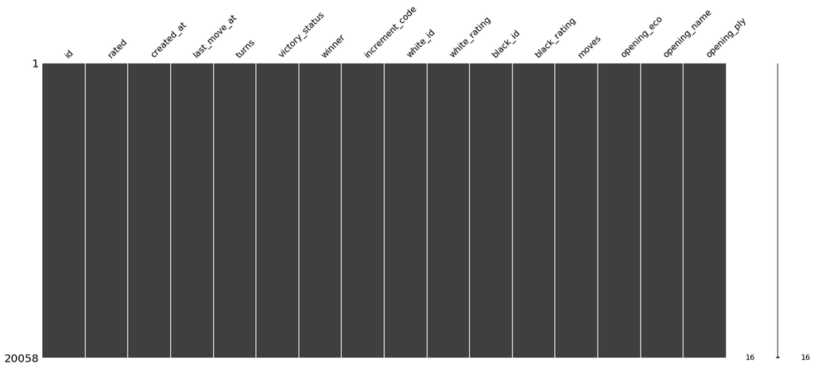

```python
# This code is taken from course notebook
#import missingno as mn
mn.matrix(chess_original.sort_values(by=["id",]))
```

To understand the data, the first thing to do would be to check whether there is any "NA" in the dataset. Based on the plot above, there is no missing value in the data, which is ideal for analysis.

### Add 10 Moves Separately

```python
def get_move_titles(move_list, idx):
    unique_game_openings_title=[]
    unique= np.unique(move_list)
    for game_num in range(len(unique)):
        name = str(game_num)
        name = idx + name
        unique_game_openings_title.append(name)
    return unique_game_openings_title

ten_moves = chess_cat.ten_moves
print(ten_moves[0])

def get_x_move(move_list, num_move):
    move = []
    for game in move_list:
        if len(game) > num_move:
            move.append(game[num_move])
        else:
            move.append('game over')
    return move

first = get_x_move(ten_moves, 0)
#print(first)
second = get_x_move(ten_moves, 1)
#print(second)
third = get_x_move(ten_moves, 2)
fourth = get_x_move(ten_moves, 3)
fifth = get_x_move(ten_moves, 4)
sixth = get_x_move(ten_moves, 5)
seventh = get_x_move(ten_moves, 6)
eighth = get_x_move(ten_moves, 7)
ninth = get_x_move(ten_moves, 8)
tenth = get_x_move(ten_moves, 9)
```

```
['d4', 'd5', 'c4', 'c6', 'cxd5', 'e6', 'dxe6', 'fxe6', 'Nf3', 'Bb4+']
```

```python
chess_onehot = add_feature(chess_onehot, 'first', first)
chess_onehot = add_feature(chess_onehot, 'second', second)
chess_onehot = add_feature(chess_onehot, 'third', third)
chess_onehot = add_feature(chess_onehot, 'fourth', fourth)
chess_onehot = add_feature(chess_onehot, 'fifth', fifth)
chess_onehot = add_feature(chess_onehot, 'sixth', sixth)
chess_onehot = add_feature(chess_onehot, 'seventh', seventh)
chess_onehot = add_feature(chess_onehot, 'eighth', eighth)
chess_onehot = add_feature(chess_onehot, 'ninth', ninth)
chess_onehot = add_feature(chess_onehot, 'tenth', tenth)
```

```python
chess_cat = add_feature(chess_cat, 'first', first)
chess_cat = add_feature(chess_cat, 'second', second)
chess_cat = add_feature(chess_cat, 'third', third)
chess_cat = add_feature(chess_cat, 'fourth', fourth)
chess_cat = add_feature(chess_cat, 'fifth', fifth)
chess_cat = add_feature(chess_cat, 'sixth', sixth)
chess_cat = add_feature(chess_cat, 'seventh', seventh)
chess_cat = add_feature(chess_cat, 'eighth', eighth)
chess_cat = add_feature(chess_cat, 'ninth', ninth)
chess_cat = add_feature(chess_cat, 'tenth', tenth)
```

```python
chess_regression = add_feature(chess_regression, 'first', first)
chess_regression = add_feature(chess_regression, 'second', second)
chess_regression = add_feature(chess_regression, 'third', third)
chess_regression = add_feature(chess_regression, 'fourth', fourth)
chess_regression = add_feature(chess_regression, 'fifth', fifth)
chess_regression = add_feature(chess_regression, 'sixth', sixth)
chess_regression = add_feature(chess_regression, 'seventh', seventh)
chess_regression = add_feature(chess_regression, 'eighth', eighth)
chess_regression = add_feature(chess_regression, 'ninth', ninth)
chess_regression = add_feature(chess_regression, 'tenth', tenth)
```

```python
chess_onehot_each_move = chess_onehot
print(chess_onehot_each_move.info())
print(np.unique(first))
```

```
<class 'pandas.core.frame.DataFrame'>
RangeIndex: 20058 entries, 0 to 20057
Data columns (total 28 columns):
turns             20058 non-null int64
increment_code    20058 non-null object
white_rating      20058 non-null int64
black_rating      20058 non-null int64
opening_ply       20058 non-null int64
False             20058 non-null uint8
True              20058 non-null uint8
black             20058 non-null uint8
draw              20058 non-null uint8
white             20058 non-null uint8
A                 20058 non-null uint8
B                 20058 non-null uint8
C                 20058 non-null uint8
D                 20058 non-null uint8
E                 20058 non-null uint8
base              20058 non-null int64
increment         20058 non-null int64
maxtime           20058 non-null int64
first             20058 non-null object
second            20058 non-null object
third             20058 non-null object
fourth            20058 non-null object
fifth             20058 non-null object
sixth             20058 non-null object
seventh           20058 non-null object
eighth            20058 non-null object
ninth             20058 non-null object
tenth             20058 non-null object
dtypes: int64(7), object(11), uint8(10)
memory usage: 2.9+ MB
None
['Na3' 'Nc3' 'Nf3' 'Nh3' 'a3' 'a4' 'b3' 'b4' 'c3' 'c4' 'd3' 'd4' 'e3' 'e4'
 'f3' 'f4' 'g3' 'g4' 'h3' 'h4']
```

```python
def one_hot_encode_each_move(df, name, cat_columns):
    '''
    Input: dataframe, name of feaure, categories of the column
    Output: dataframe with one hot encoded feature added
    '''
    if name in df:
        name = pd.get_dummies(df[name],prefix_sep='_',columns=cat_columns)
    #name
    return pd.concat([df, name], axis = 1)

    # Rated should be one-hot encoded for chess_onehot

#rated_dummy = one_hot_encode(chess_regression, 'rated' , [True, False])
#chess_regression = pd.concat([chess_regression, rated_dummy], axis=1)
```

```python
# one hot encode for each move
chess_onehot = one_hot_encode_each_move(chess_onehot,"first",np.unique(first))
#print(chess_onehot_each_move)
chess_onehot = one_hot_encode_each_move(chess_onehot, "second", np.unique(second))
chess_onehot = one_hot_encode_each_move(chess_onehot_each_move,"third",get_move_titles(third, '3'))
chess_tsen = one_hot_encode_each_move(chess_onehot_each_move,"fourth",get_move_titles(fourth, '4'))
chess_onehot = one_hot_encode_each_move(chess_onehot_each_move,"fifth",get_move_titles(fifth, '5'))
chess_onehot = one_hot_encode_each_move(chess_onehot_each_move,"sixth",get_move_titles(sixth, '6'))
chess_onehot = one_hot_encode_each_move(chess_onehot_each_move,"seventh",get_move_titles(seventh, '7'))
chess_onehot = one_hot_encode_each_move(chess_onehot_each_move,"eighth",get_move_titles(eighth, '8'))
chess_onehot = one_hot_encode_each_move(chess_onehot_each_move,"ninth",get_move_titles(ninth, '9'))
chess_onehot = one_hot_encode_each_move(chess_onehot_each_move,"tenth",get_move_titles(tenth, '10'))

#print(len(unique_game_openings_title))
print(chess_onehot.info())
```

```
<class 'pandas.core.frame.DataFrame'>
RangeIndex: 20058 entries, 0 to 20057
Columns: 435 entries, turns to hxg6
dtypes: int64(7), object(11), uint8(417)
memory usage: 10.7+ MB
None
```

# ADD SCORE OF TEN MOVES

```python
# Read in Scores made Earlier different computer
chess_cat3 = pd.read_excel('/Users/KobeInc/Desktop/chess_pd_moves.xlsx')
```

# Code that was Used to create Score Data

```python
# The following code is adapted from the documentation for python chess
# For this code to run, you have to have installed stockfish on your computer
#https://python-chess.readthedocs.io/en/latest/engine.html#analysing-and-evaluating-a-position
#import chess
#import chess.engine

file_engine = '/Users/chandlerjburke/Documents/SMU_Masters/Fall_2019/ML_Python/stockfish-10-mac/src/stockfish'
#engine = chess.engine.SimpleEngine.popen_uci(file_engine)
def create_score(moves_list, engine, time):
    '''
    Input: moves as a list,
    Output: score from the engine
    '''
    #engine = chess.engine.SimpleEngine.popen_uci(file_engine)
    score = []
    if (idx % 1000 == 0):
        print(idx)
    for idx, moves in enumerate(moves_list):
        board = chess.Board()
        for move in moves:
            board.push_san(move)
        info = engine.analyse(board, chess.engine.Limit(time=time))
        score.append(info['score'])
    return score

#score = create_score(ten_moves, engine, 0.05)
#print("Score:", info["score"])

# Score: +20
```

```python
def convert_pov_int(score):
    '''
    Input: score from stockfish
    Output: integer
    '''
    if ('#' in str(score)):
        return 0
    else:
        return int(str(score))
```

```python
def convert_all_scores(scores):
    '''
    Input: scores as a chess engine mov object
    Output: scores as a list of integers
    '''
    scores_int = []
    for score in scores:
        scores_int.append(convert_pov_int(score))
    return scores_int

#score_int = convert_all_scores(score)
```

# Calculate Statistics of Winner vs Score

```python
white_win_score = []
black_win_score = []
draw_score = []

for (idx, val) in enumerate(chess_cat3['stockfish']):
    if (chess_cat3['winner'][idx] == 'white'):
        white_win_score.append(chess_cat3['stockfish'][idx])
    elif (chess_cat3['winner'][idx] == 'black'):
        black_win_score.append(chess_cat3['stockfish'][idx])
    else:
        draw_score.append(chess_cat3['stockfish'][idx])

print('Number of games White won: ' + str(len(white_win_score)))
print('Number of games Black won: ' + str(len(black_win_score)))
print('Number of games drawn: ' + str(len(draw_score)))

print('White Win Average Score: ' + str(np.round(np.mean(white_win_score))))
print('Black Win Average Score: ' + str(np.round(np.mean(black_win_score))))
print('Draw Average Score: ' + str(np.round(np.mean(draw_score))))
```

```
Number of games White won: 10001
Number of games Black won: 9107
Number of games drawn: 950
White Win Average Score: 117.0
Black Win Average Score: 43.0
Draw Average Score: 81.0
```

# Add 10 Moves Score

```python
def filter_short_games(df, name, num_turns):
    '''
    Input:dataframe, name of feature turns, number of turns
    Output: dataframe, number of turns less than 10
    '''
    df = df[df[name] > num_turns]
    return df
```

```python
def filter_long_opening(df, name, num_turns):
    '''
    Input:dataframe,number of turns
    Output: dataframe, number of turns less than 10
    '''
    df = df[df[name]<num_turns]
    return df
```

```python
chess_regression = filter_short_games(chess_regression, 'turns', 10)
chess_regression = filter_long_opening(chess_regression, 'opening_ply', 10)
```

```python
chess_onehot = filter_short_games(chess_onehot, 'turns', 10)
chess_onehot = filter_long_opening(chess_onehot, 'opening_ply', 10)
```

```python
chess_cat = filter_short_games(chess_cat, 'turns', 10)
chess_cat = filter_long_opening(chess_cat, 'opening_ply', 10)
```

```python
chess_cat3 = filter_short_games(chess_cat3, 'turns', 10)
chess_cat3 = filter_long_opening(chess_cat3, 'opening_ply', 10)
```

```python
chess_cat3.info()
```

```
<class 'pandas.core.frame.DataFrame'>
Int64Index: 18047 entries, 0 to 20057
Data columns (total 12 columns):
Unnamed: 0        18047 non-null int64
rated             18047 non-null bool
turns             18047 non-null int64
winner            18047 non-null object
increment_code    18047 non-null object
white_rating      18047 non-null int64
black_rating      18047 non-null int64
moves             18047 non-null object
opening_eco       18047 non-null object
opening_ply       18047 non-null int64
ten_moves         18047 non-null object
stockfish         18047 non-null int64
dtypes: bool(1), int64(6), object(5)
memory usage: 1.7+ MB
```

```python
for (idx, val) in enumerate(chess_cat3['stockfish']):
    #print(idx)
    #print(val)
    arra = chess_cat3['winner']
    #print(arra[idx] == 'white')
```

# Add Score to Dataframes

```python
chess_regression = add_feature(chess_regression, 'stockfish', chess_cat3['stockfish'])
chess_onehot = add_feature(chess_onehot, 'stockfish', chess_cat3['stockfish'])
chess_cat = add_feature(chess_cat, 'stockfish', chess_cat3['stockfish'])
```

# NEW FOR LAB 5

```python
print(chess_regression.head())
```

```
   turns winner increment_code  white_rating  black_rating  opening_ply  \
0     13  white           15+2          1500          1191            5
1     16  black           5+10          1322          1261            4
2     61  white           5+10          1496          1500            3
3     61  white           20+0          1439          1454            3
4     95  white           30+3          1523          1469            5

   False  True  A  B  ...  second  third  fourth  fifth  sixth  seventh  \
0      1     0  0  0  ...      d5     c4      c6   cxd5     e6     dxe6
1      0     1  0  1  ...     Nc6     e4      e5     f4     f6     dxe5
2      0     1  0  0  ...      e5     d3      d6    Be3     c6      Be2
3      0     1  0  0  ...      d5    Nf3     Bf5    Nc3    Nf6      Bf4
4      0     1  0  0  ...      e5    Nf3      d6     d4    Nc6       d5

  eighth ninth tenth stockfish
0   fxe6   Nf3  Bb4+       328
1   fxe5  fxe5  Nxe5        74
2     b5   Nd2    a5       175
3    Ng4    e3   Nc6       261
4    Nb4    a3   Na6       172

[5 rows x 27 columns]
```

```python
print(chess_cat.info())
```

```
<class 'pandas.core.frame.DataFrame'>
Int64Index: 18047 entries, 0 to 20057
Data columns (total 24 columns):
rated               18047 non-null bool
turns               18047 non-null int64
winner              18047 non-null category
increment_code      18047 non-null object
white_rating        18047 non-null int64
black_rating        18047 non-null int64
opening_eco         18047 non-null object
opening_ply         18047 non-null int64
ten_moves           18047 non-null object
opening_category    18047 non-null object
base                18047 non-null int64
increment           18047 non-null int64
maxtime             18047 non-null int64
first               18047 non-null object
second              18047 non-null object
third               18047 non-null object
fourth              18047 non-null object
fifth               18047 non-null object
sixth               18047 non-null object
seventh             18047 non-null object
eighth              18047 non-null object
ninth               18047 non-null object
tenth               18047 non-null object
stockfish           18047 non-null int64
dtypes: bool(1), category(1), int64(8), object(14)
memory usage: 3.2+ MB
None
```

```python
print(chess_onehot.head())
```

```
   turns increment_code  white_rating  black_rating  opening_ply  False  True  \
0     13           15+2          1500          1191            5      1     0
1     16           5+10          1322          1261            4      0     1
2     61           5+10          1496          1500            3      0     1
3     61           20+0          1439          1454            3      0     1
4     95           30+3          1523          1469            5      0     1

   black  draw  white  ...  gxh4  gxh5  gxh6  h4  h5  h6  hxg4  hxg5 hxg6  \
0      0     0      1  ...     0     0     0   0   0   0     0     0    0
1      1     0      0  ...     0     0     0   0   0   0     0     0    0
2      0     0      1  ...     0     0     0   0   0   0     0     0    0
3      0     0      1  ...     0     0     0   0   0   0     0     0    0
4      0     0      1  ...     0     0     0   0   0   0     0     0    0

  stockfish
0       328
1        74
2       175
3       261
4       172

[5 rows x 436 columns]
```

```python
y=select_feature(chess_cat,"winner")
x=remove_feature(chess_cat,"winner")
print(x.head())
```

```
   rated  turns increment_code  white_rating  black_rating opening_eco  \
0  False     13           15+2          1500          1191         D10
1   True     16           5+10          1322          1261         B00
2   True     61           5+10          1496          1500         C20
3   True     61           20+0          1439          1454         D02
4   True     95           30+3          1523          1469         C41

   opening_ply                                          ten_moves  \
0            5  [d4, d5, c4, c6, cxd5, e6, dxe6, fxe6, Nf3, Bb4+]
1            4  [d4, Nc6, e4, e5, f4, f6, dxe5, fxe5, fxe5, Nxe5]
2            3        [e4, e5, d3, d6, Be3, c6, Be2, b5, Nd2, a5]
3            3    [d4, d5, Nf3, Bf5, Nc3, Nf6, Bf4, Ng4, e3, Nc6]
4            5       [e4, e5, Nf3, d6, d4, Nc6, d5, Nb4, a3, Na6]

  opening_category  base  ...  second  third fourth fifth sixth seventh  \
0                D    15  ...      d5     c4     c6  cxd5    e6    dxe6
1                B     5  ...     Nc6     e4     e5    f4    f6    dxe5
2                C     5  ...      e5     d3     d6   Be3    c6     Be2
3                D    20  ...      d5    Nf3    Bf5   Nc3   Nf6     Bf4
4                C    30  ...      e5    Nf3     d6    d4   Nc6      d5

  eighth ninth tenth stockfish
0   fxe6   Nf3  Bb4+       328
1   fxe5  fxe5  Nxe5        74
2     b5   Nd2    a5       175
3    Ng4    e3   Nc6       261
4    Nb4    a3   Na6       172

[5 rows x 23 columns]
```

```python
print(y.head())
```

```
0    white
1    black
2    white
3    white
4    white
Name: winner, dtype: category
Categories (3, object): [black, draw, white]
```

```python
y_victor = []
for victor in y:
    if victor == 'white':
        y_victor.append(1)
    else:
        y_victor.append(0)

print(len(y_victor))

data = {'winner':y_victor}

y = pd.DataFrame(data)
y_original=y

#y = add_feature(y, 'white', y_victor)
#y = remove_feature(y,'winner')
```

```
18047
```

# Add rated String

```python
rated_str = []
#print(x['rated'])
for boolean in list(x['rated']):
    rated_str.append(str(boolean))
x= add_feature(x, 'rated_str', rated_str)
```

# Training and Testing (10 Points)

# Train and test split: Use 10 fold CV

```python
lose=0
win=0
for i in range(len(y_victor)):
    if y_victor[i]==0:
        lose = lose + 1
    elif y_victor[i]==1:
        win = win + 1
print("win: " + str(win),"Not win: "  + str(lose))
```

```
win: 8972 Not win: 9075
```

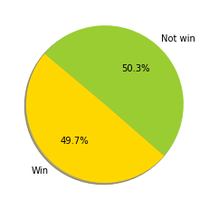

```python
# Data to plot
labels = 'Win','Not win'
sizes = [8972,9075]
colors = ['gold', 'yellowgreen']

# Plot
plt.pie(sizes,labels=labels, colors=colors,
autopct='%1.1f%%', shadow=True, startangle=140)

plt.show()
```

```python
from sklearn.model_selection import StratifiedKFold,cross_val_score
from sklearn import metrics

chess_skf=StratifiedKFold(n_splits=10)
X_train = []
X_test = []
y_train = []
y_test = []

#x  =   x.values
#y  =   y.values
for train_index,test_index in chess_skf.split(x,y):
    #print(train_index)
    #print(test_index)
    print("Train Index:",train_index,",Test Index:",test_index)
    X_train_temp, X_test_temp =x.iloc[train_index],x.iloc[test_index]
    y_train_temp ,y_test_temp =y.iloc[train_index],y.iloc[test_index]

    X_train.append(X_train_temp)
    X_test.append(X_test_temp)
    y_train.append(y_train_temp)
    y_test.append(y_test_temp)
```

```
Train Index: [ 1721  1722  1723 ... 18044 18045 18046] ,Test Index: [   0    1    2 ... 1915 1917 1919]
Train Index: [    0     1     2 ... 18044 18045 18046] ,Test Index: [1721 1722 1723 ... 3674 3675 3677]
Train Index: [    0     1     2 ... 18044 18045 18046] ,Test Index: [3541 3542 3544 ... 5476 5477 5480]
Train Index: [    0     1     2 ... 18044 18045 18046] ,Test Index: [5342 5344 5346 ... 7293 7294 7295]
Train Index: [    0     1     2 ... 18044 18045 18046] ,Test Index: [7144 7145 7148 ... 9059 9061 9062]
Train Index: [    0     1     2 ... 18044 18045 18046] ,Test Index: [ 8992  8999  9001 ... 10857 10859 10861]
Train Index: [    0     1     2 ... 18044 18045 18046] ,Test Index: [10788 10789 10792 ... 12642 12643 12646]
Train Index: [    0     1     2 ... 18044 18045 18046] ,Test Index: [12614 12615 12618 ... 14460 14461 14463]
Train Index: [    0     1     2 ... 18044 18045 18046] ,Test Index: [14415 14420 14421 ... 16280 16281 16282]
Train Index: [    0     1     2 ... 16280 16281 16282] ,Test Index: [16190 16191 16192 ... 18044 18045 18046]
```

## Explanation for using 10 fold Cross-validation

As you can see above, we have 8972 samples that are win, 9075 samples that are either lose or a draw. However,we have to pay attention to our sample size since it is small. From the counts of two categories, after we do a 80/20 split for train and test set, we only have 8972/5=1794.4 samples of win in the test set. It is not enough, and we can get almost any performance on this set only due to chance. In K Fold cross validation, the data is divided into k subsets.

Now the holdout method is repeated k times, such that each time, one of the k subsets is used as the test set/ validation set and the other k-1 subsets are put together to form a training set. The error estimation is averaged over all k trials to get total effectiveness of our model. As can be seen, every data point gets to be in a validation set exactly once, and gets to be in a training set k-1 times. This significantly reduces bias as we are using most of the data for fitting, and also significantly reduces variance as most of the data is also being used in validation set. As a general rule and empirical evidence, K = 5 or 10 is generally preferred as it is often reported that the optimal k is between 5 and 10 , because the statistical performance does not increase a lot for larger values of k. So for our problem, using a 5/10 fold cross validation method to do an 80/20 split is a better way. Since we also want the same proportion of different classes in each fold, Stratified 10-fold is a better choice.

```python
cat_names = ['rated_str', 'increment_code', 'opening_eco', 'ten_moves', 'opening_category',
            'first', 'second', 'third', 'fourth', 'fifth', 'sixth', 'seventh', 'eighth', 'ninth', 'tenth']

numeric_names = ['turns', 'white_rating', 'black_rating', 'opening_ply',
                 'base', 'increment', 'maxtime', 'stockfish']
```

```python
X_train[0]
```

[output not shown]

16241 rows × 24 columns

```python
# Code Copied from Larson ML Code for Wide and Deep Networks

from sklearn.preprocessing import LabelEncoder
from sklearn.preprocessing import StandardScaler

# define objects that can encode each variable as integer
encoders = dict()


# removed rated temporarily
categorical_headers = ['rated_str', 'increment_code', 'opening_eco', 'opening_category',
            'first', 'second', 'third', 'fourth', 'fifth', 'sixth', 'seventh', 'eighth', 'ninth', 'tenth']

#categorical_headers = ['opening_category', 'first', 'second']
# train all encoders (special case the target 'income')
for col in categorical_headers:
    print(col)
    for i in [0,1,2,3,4,5,6,7,8,9]:

        X_train[i][col] = X_train[i][col].str.strip()
        X_test[i][col] = X_test[i][col].str.strip()
        #y_train[0][col] = y_train[0][col].str.strip()
        #y_test[0][col] = y_test[0][col].str.strip()


        # integer encoded variables
        encoders[col] = LabelEncoder() # save the encoder
        X_all = X_train[i].append(X_test[i])
        model = encoders[col].fit(X_all[col])
        X_train[i][col+'_int'] = encoders[col].transform(X_train[i][col])
        X_test[i][col +'_int'] = encoders[col].transform(X_test[i][col])
```

```
rated_str
```

```
increment_code
opening_eco
opening_category
first
second
third
fourth
fifth
sixth
seventh
eighth
ninth
tenth
```

```python
# Code Copied from Larson ML Code for Wide and Deep Networks



# scale the numeric, continuous variables
numeric_headers = ['turns', 'white_rating', 'black_rating', 'opening_ply',
                 'base', 'increment', 'maxtime', 'stockfish']

for col in numeric_headers:
    for i in [0,1,2,3,4,5,6,7,8,9]:
        X_train[i][col] = X_train[i][col].astype(np.float)
        X_test[i][col] = X_test[i][col].astype(np.float)

        ss = StandardScaler()
        X_train[i][col] = ss.fit_transform(X_train[i][col].values.reshape(-1, 1))
        X_test[i][col] = ss.transform(X_test[i][col].values.reshape(-1, 1))

X_test[0].head()
```

[output not shown]

[output cut: 1865 more lines]

[output not shown]

|  | rated | turns | increment_code | white_rating | black_rating | opening_eco | opening_ply | ten_moves | opening_category | base | ... | first_int | second_int | third_int | fourth_int | fifth_int | sixth_int | seventh_int | eighth_int | ninth_int | tenth_int |
| --- | --- | --- | --- | --- | --- | --- | --- | --- | --- | --- | --- | --- | --- | --- | --- | --- | --- | --- | --- | --- | --- |
| 0 | False | -1.520687 | 15+2 | -0.322206 | -1.402675 | D10 | 0.302863 | [d4, d5, c4, c6, cxd5, e6, dxe6, fxe6, Nf3, Bb4+] | D | 0.092711 | ... | 11 | 10 | 52 | 66 | 135 | 189 | 237 | 286 | 127 | 6 |
| 1 | True | -1.428233 | 5+10 | -0.956662 | -1.152777 | B00 | -0.178522 | [d4, Nc6, e4, e5, f4, f6, dxe5, fxe5, fxe5, Nxe5] | B | -0.539440 | ... | 11 | 1 | 62 | 75 | 156 | 199 | 236 | 285 | 328 | 192 |
| 2 | True | -0.041416 | 5+10 | -0.336464 | -0.299551 | C20 | -0.659908 | [e4, e5, d3, d6, Be3, c6, Be2, b5, Nd2, a5] | C | -0.539440 | ... | 13 | 12 | 56 | 71 | 12 | 168 | 15 | 237 | 112 | 322 |
| 3 | True | -0.041416 | 20+0 | -0.539632 | -0.463770 | D02 | -0.659908 | [d4, d5, Nf3, Bf5, Nc3, Nf6, Bf4, Ng4, e3, Nc6] | D | 0.408787 | ... | 11 | 10 | 27 | 9 | 45 | 71 | 20 | 111 | 310 | 128 |
| 4 | True | 1.006401 | 30+3 | -0.240226 | -0.410220 | C41 | 0.302863 | [e4, e5, Nf3, d6, d4, Nc6, d5, Nb4, a3, Na6] | C | 1.040938 | ... | 13 | 12 | 27 | 71 | 137 | 59 | 229 | 82 | 268 | 115 |

5 rows × 38 columns

```python
!pip install keras
!pip install tensorflow

from sklearn import metrics as mt
import keras

keras.__version__

# from keras.models import Sequential
from keras.layers import Dense, Activation, Input
from keras.layers import Embedding, Flatten, Concatenate
from keras.models import Model

from sklearn import metrics as mt

from sklearn.preprocessing import OneHotEncoder

# combine the features with two branches
from keras.layers import concatenate

from IPython.display import SVG
from keras.utils.vis_utils import model_to_dot
```

# Modeling (50 points total)

# Cross-product features identification

For our data set, the opening_category is basicly a subset of opening_eco. We expect that would indicate a perfect relationship. We also think increment_code and rated_str may be related to each other so we want to cross this two features to check if they are associated. The easiest way would be the moves data. There can be a combination of first and second, first to fifth, or first to tenteh. In this way, we can have various numbers of moves and see how that will effect our results.

Therefore, we believe these features are related and crossing them would help our network to memorize these relations to improve quality of our prediction.

```python
cross_columns1 = [['opening_category', 'opening_eco'],
                 ['increment_code', 'rated_str'],
                 ['first','second']]

cross_columns2 = [['opening_category', 'opening_eco'],
                 ['increment_code', 'rated_str'],
                 ['first','second', 'third', 'fourth', 'fifth']]

cross_columns3 = [['opening_category', 'opening_eco'],
                 ['increment_code', 'rated_str'],
                 ['first','second', 'third', 'fourth', 'fifth', 'sixth', 'seventh', 'eighth', 'ninth', 'tenth']]
```

```python
import keras.backend as K

def brier_score(y_true, y_pred):
    return K.mean((y_true - y_pred)**2)

def brier_score_calc(y_true, y_pred):
    return np.mean((y_true-y_pred)**2)
```

```python
from matplotlib import pyplot as plt
def cross_validation_wide_deep(X_train, X_test, y_train, y_test, cross_columns):
    '''
    input: X_train, X_test, y_train, y_test, cross_columns
    Output: accuracy using cross_validation_wide_deep
    '''
    history=[]
    brier_score_lst = []

    for i in [0,1,2,3,4,6,7,8,9]:

        # we need to create separate sequential models for each embedding
        embed_branches = []
        X_ints_train = [] # keep track of inputs for each branch
        X_ints_test = []# keep track of inputs for each branch
        all_inputs = [] # this is what we will give to keras.Model inputs
        all_branch_outputs = [] # this is where we will keep track of output of each branch


        for cols in cross_columns:
            # encode as ints for the embedding
            enc = LabelEncoder()

            # 1. create crossed labels by join operation
            X_crossed_train = X_train[i][cols].apply(lambda x: '_'.join(x), axis=1)
            X_crossed_test = X_test[i][cols].apply(lambda x: '_'.join(x), axis=1)

            # 2. encode as integers
            enc.fit(np.hstack((X_crossed_train.values,  X_crossed_test.values)))
            X_crossed_train = enc.transform(X_crossed_train)
            X_crossed_test = enc.transform(X_crossed_test)

            # 3. save encodings in a list for each branch
            X_ints_train.append( X_crossed_train )
            X_ints_test.append( X_crossed_test )

            # get the number of categories in the crossing
            N = max(np.hstack((X_ints_train[-1],X_ints_test[-1])))+1 # same as the max(df_train[col]
            #print(N)

            # create embedding branch from the number of categories
            inputs = Input(shape=(1,),dtype= 'int32', name='_'.join(cols))
            all_inputs.append( inputs ) # keep track of created inputs
            x = Embedding(input_dim=N,
                          output_dim=int(np.sqrt(N)),
                          input_length=1, name='_'.join(cols)+'_embed')(inputs)
            x = Flatten()(x)
            all_branch_outputs.append(x)



        X_train_num = X_train[i][numeric_headers]
        # also get a dense branch of the numeric features


       # X_train_ints_j = X_train_ints.tolist()
       # X_train_num_j = X_train_num.tolist()
       #X_test_ints = X_train_ints + [X_train_num]
       # X_test_num = X_test_num.tolist()
       # X_train = X_train_ints + [X_train_num]
       # X_test = X_test_ints+[X_test_num]

        all_inputs.append(Input(shape=(X_train_num.shape[1],),sparse=False, name='numeric'))
        x = Dense(units=20, activation='relu',name='numeric_1')(all_inputs[-1])
        all_branch_outputs.append( Dense(units=10,activation='relu', name='numeric_2')(x) )

        # merge the branches together
        final_branch = concatenate(all_branch_outputs, name='concat_1')
        final_branch = Dense(units=1,activation='sigmoid', name='combined')(final_branch)

        model = Model(inputs=all_inputs, outputs=final_branch)


        # Added for dimensionality reasons
        #X_ints = np.array(model[1])
        #X_num = np.array(model[2])

        #tester = np.concatenate(X_ints.T, X_nums, axis = 1)


        #X_train_ints = (X_train[:,:(len(cross_columns))].T).tolist()
        #X_train_num = X_train[:,len(cross_columns):].tolist()
       #
        #X_test_ints = X_train_its + [X_train_num]
        #X_test_num = X_test[:,9:].tolist()

        #X_train = X_train_ints + [X_train_num]
        #X_test = X_test_ints+[X_test_num]



        model.compile(optimizer='sgd',
              loss='binary_crossentropy',
              metrics= [brier_score, 'accuracy'])






        history = model.fit(X_ints_train + [X_train_num], # create a list of inputs for embeddings
        y_train[i], epochs=10, batch_size=32, verbose=1) #change epochs later

        X_test_num = X_test[i][numeric_headers].values
        print(len(X_ints_test))
        print(X_test_num)
        yhat = np.round(model.predict(X_ints_test + [X_test_num]))
        print(mt.confusion_matrix(y_test[i],yhat),mt.roc_auc_score(y_test[i],yhat))
        brier_score_lst.append(brier_score_calc(yhat, y_test[i]))


        #Also add the visulization part use the "history" return parameter

        plt.figure(figsize=(12,8))
        plt.subplot(1,3,1)
        plt.plot(history.history['accuracy'])
        plt.ylabel('Accuracy %')
        plt.title('Training')

        plt.subplot(1,3,2)
        plt.plot(history.history['brier_score'])
        plt.ylabel('brier_score %')
        plt.title('Validation')

        plt.subplot(1,3,3)
        plt.plot(history.history['loss'])
        plt.ylabel('MSE Training Loss')
        plt.xlabel('epochs')

    return model
```

```
3
[[-1.52068729 -0.32220627 -1.40267539 ... -0.23127184 -0.05971883
   1.2731593 ]
 [-1.42823283 -0.95666248 -1.15277665 ...  0.40758619 -0.14327271
  -0.07188385]
 [-0.04141598 -0.33646371 -0.29955096 ...  0.40758619 -0.14327271
   0.46295614]
 ...
 [-0.84268794  0.56175519 -0.16746163 ... -0.23127184 -0.26860353
   0.35175178]
 [-1.58232359 -0.8461673  -0.05679219 ...  0.00829992  0.065612
  -0.5431785 ]
 [-1.58232359 -0.78913753  0.09671703 ...  0.00829992 -0.14327271
   2.07277157]]
[[555 353]
 [308 590]] 0.6341245351883285
```

```
3
[[-0.50607809 -0.97134626 -0.37236561 ... -0.38379632 -0.34391268
   0.20744003]
 [-0.62914647 -0.37970319  1.90832008 ... -0.38379632 -0.34391268
  -0.04374525]
 [ 0.84767411  0.49890449 -0.64816946 ... -0.38379632 -0.34391268
   0.68250786]
 ...
 [ 0.50923606 -0.71626661 -1.50033265 ...  0.24000293 -0.01745029
   0.61698127]
 [-0.59837937 -1.59841706 -1.83624759 ...  0.78582727  0.2682043
   0.30572993]
 [ 0.47846897 -1.37876514 -1.40839803 ... -0.38379632 -0.13987369
   0.46954642]]
[[617 291]
 [310 588]] 0.6671519186052215
```

```
3
[[-1.24874226 -1.15400709 -1.11859401 ... -0.39206413  0.50984451
  -0.37129535]
 [ 0.10813878 -1.10396718 -1.07570526 ... -0.39206413 -0.35151047
  -0.22740668]
 [-1.00203662 -0.31047725 -1.07927932 ...  0.01079959 -0.13617173
  -2.114562  ]
 ...
 [-0.35443431  0.65457807 -1.1936493  ... -0.06977316 -0.35151047
   0.26513533]
 [-0.72449277  0.64385524 -0.56104035 ...  0.25251781 -0.13617173
   0.89049765]
 [-1.15622764 -0.31047725 -1.20794555 ... -0.39206413  0.50984451
   1.90878673]]
[[590 318]
 [290 607]] 0.6632399235827698
```

```
3
[[-0.25272091 -0.8192888   0.59750029 ... -0.39265667 -0.34885046
   0.00597647]
 [-0.56164175 -0.80874689  1.85026818 ... -0.39265667 -0.34885046
  -1.23337682]
 [ 0.1179841  -0.73143959  0.52380806 ... -0.39265667 -0.34885046
  -0.14757172]
 ...
 [-0.96323884  0.95877919  1.01508959 ... -0.39265667 -0.13623191
   0.06081511]
 [-1.45751218  0.23138774  0.44660668 ... -0.39265667 -0.13623191
   0.11565376]
 [-1.21037551 -0.31327735 -0.45875498 ... -0.39265667 -0.13623191
   0.3843631 ]]
[[648 260]
 [355 542]] 0.6589463655159882
```

```
3
[[ 0.41958267 -0.29977691 -0.27706732 ...  0.26887291 -0.22394633
  -0.45790154]
 [ 1.70884597 -0.29977691 -0.27706732 ...  4.55796086  2.65067221
  -0.64724373]
 [ 1.61675573 -0.99066387 -1.02696359 ... -0.39098677 -0.3526606
  -0.44708199]
 ...
 [-0.96177088  0.31708645  0.5045147  ... -0.39098677  0.50543449
   0.84585469]
 [-0.40922946  0.42988433 -0.61504874 ... -0.39098677  0.50543449
  -0.78789793]
 [ 0.26609894  0.39463499  0.28623503 ... -0.39098677  0.50543449
  -0.73920994]]
[[587 321]
 [297 600]] 0.6576860459976721
```

```
3
[[ 1.64774079 -1.51987703 -1.34313865 ... -0.39149445 -0.34974646
   0.6285661 ]
 [-0.33768043  2.73310855  2.05361046 ...  1.58631232  0.67506354
  -0.10452257]
 [ 0.22071929  3.1012241   2.05361046 ...  2.77299638  1.08498753
   0.05256786]
 ...
 [-0.83403574  0.13485602  0.44237764 ... -0.39149445 -0.34974646
  -0.61244828]
 [-1.1132356   0.38860558  0.14004918 ... -0.39149445 -0.34974646
  -0.21972221]
 [-1.51652429  3.46576573 -0.52507342 ... -0.23326991 -0.26776166
  -0.20924952]]
[[621 286]
 [362 535]] 0.6405536524418649
```

```
3
[[ 0.36594124 -0.9859695  -0.28019747 ...  0.47446353 -0.02380558
  -0.07584189]
 [-0.74830613 -0.30507035 -0.28019747 ...  0.0818489  -0.1055635
  -0.62911979]
 [ 0.73735703 -0.30507035  0.21062138 ... -0.23224281 -0.35083727
  -0.07052191]
 ...
 [-0.99591666  0.15120228  0.34384364 ... -0.38928866 -0.35083727
  -0.2301213 ]
 [ 1.29448071  0.1792806   0.62080571 ... -0.38928866 -0.35083727
  -0.00136217]
 [ 0.36594124  0.28457428 -1.20223575 ... -0.38928866 -0.35083727
   0.31251663]]
[[606 301]
 [334 563]] 0.6478922145237278
```

```
3
[[-1.14584475  2.54046951  1.07890189 ... -0.22801267 -0.26552761
  -0.15143598]
 [-0.52803791 -0.98549187 -1.04379036 ... -0.38384587 -0.34670673
   0.70825354]
 [ 1.32538262 -1.68154406 -1.40517433 ... -0.38384587 -0.34670673
  -0.94704926]
 ...
 [ 1.23271159 -1.11556223 -0.25435936 ...  0.31740354 -0.10316939
  -0.73880149]
 [ 2.46832528 -1.14720096  0.73506083 ...  0.31740354 -0.10316939
  -0.81889678]
 [ 0.55312407 -1.1085314  -1.07185902 ...  0.31740354 -0.10316939
  -0.58929027]]
[[636 271]
 [351 546]] 0.6549542207947845
```

```
3
[[-0.76997614  1.6632963   0.81276879 ...  0.03209123 -0.33687707
  -0.00529247]
 [-1.20466427  1.07945953  0.86237186 ... -0.37757389 -0.33687707
   0.14322583]
 [-0.21109141  0.81958097  0.17855813 ...  0.11402426 -0.33687707
   0.58878072]
 ...
 [-0.83207445 -1.28436738 -1.01545858 ... -0.37757389 -0.33687707
   0.21748498]
 [ 1.46556278 -0.78241016 -1.22450008 ... -0.37757389 -0.33687707
  -0.8857938 ]
 [ 0.50303908 -1.22740769 -0.82767554 ... -0.37757389 -0.33687707
   0.4137413 ]]
[[603 304]
 [323 574]] 0.6523699603849165
```

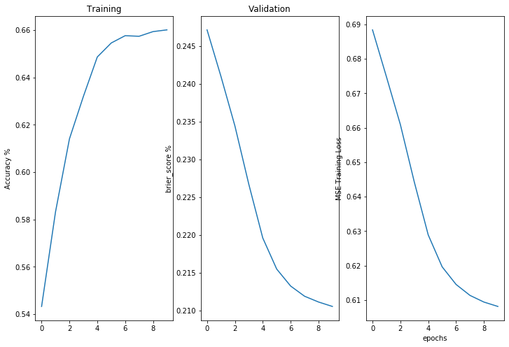

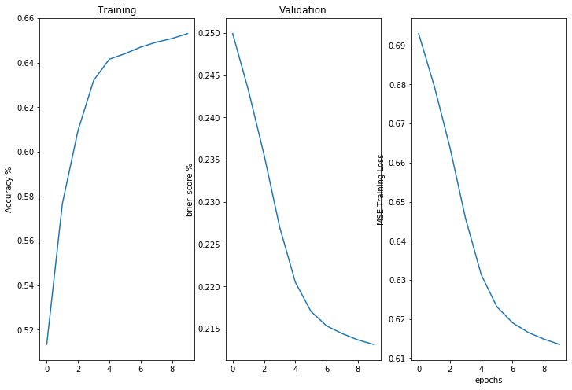

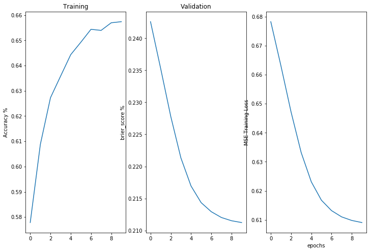

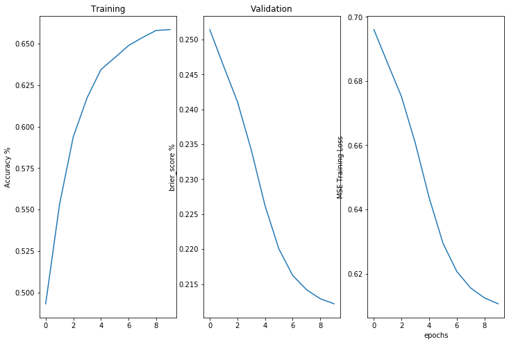

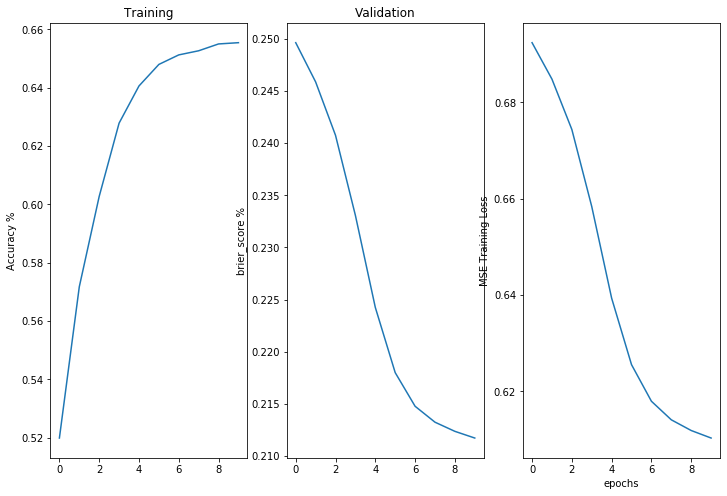

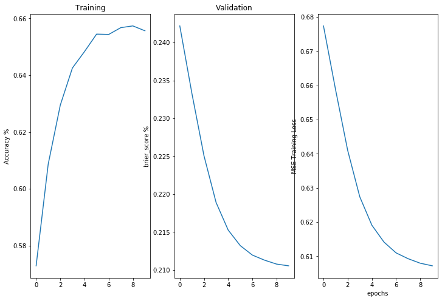

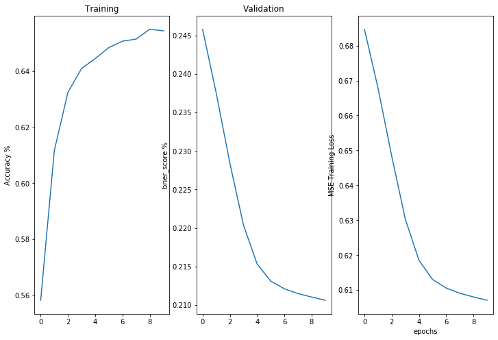

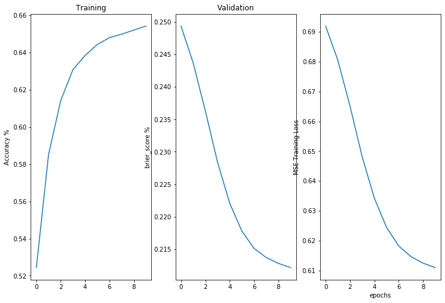

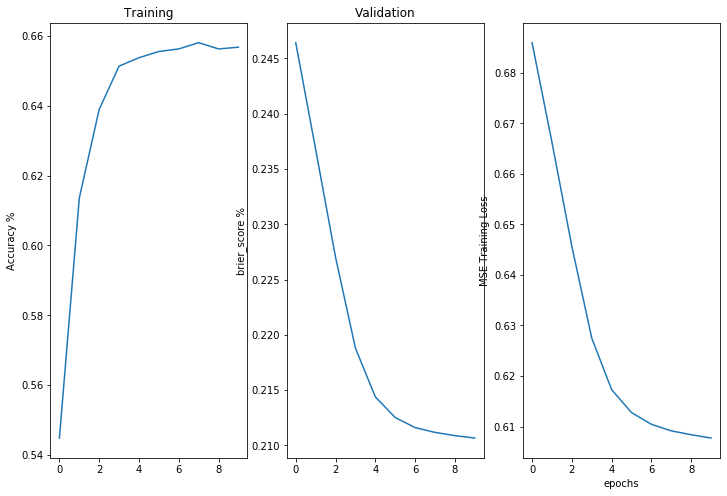

```python
model1 = cross_validation_wide_deep(X_train, X_test, y_train, y_test, cross_columns1)
```

```
3
[[-1.52068729 -0.32220627 -1.40267539 ... -0.23127184 -0.05971883
   1.2731593 ]
 [-1.42823283 -0.95666248 -1.15277665 ...  0.40758619 -0.14327271
  -0.07188385]
 [-0.04141598 -0.33646371 -0.29955096 ...  0.40758619 -0.14327271
   0.46295614]
 ...
 [-0.84268794  0.56175519 -0.16746163 ... -0.23127184 -0.26860353
   0.35175178]
 [-1.58232359 -0.8461673  -0.05679219 ...  0.00829992  0.065612
  -0.5431785 ]
 [-1.58232359 -0.78913753  0.09671703 ...  0.00829992 -0.14327271
   2.07277157]]
[[589 319]
 [322 576]] 0.6450519019259637
```

```
3
[[-0.50607809 -0.97134626 -0.37236561 ... -0.38379632 -0.34391268
   0.20744003]
 [-0.62914647 -0.37970319  1.90832008 ... -0.38379632 -0.34391268
  -0.04374525]
 [ 0.84767411  0.49890449 -0.64816946 ... -0.38379632 -0.34391268
   0.68250786]
 ...
 [ 0.50923606 -0.71626661 -1.50033265 ...  0.24000293 -0.01745029
   0.61698127]
 [-0.59837937 -1.59841706 -1.83624759 ...  0.78582727  0.2682043
   0.30572993]
 [ 0.47846897 -1.37876514 -1.40839803 ... -0.38379632 -0.13987369
   0.46954642]]
[[667 241]
 [370 528]] 0.6612773858697252
```

```
3
[[-1.24874226 -1.15400709 -1.11859401 ... -0.39206413  0.50984451
  -0.37129535]
 [ 0.10813878 -1.10396718 -1.07570526 ... -0.39206413 -0.35151047
  -0.22740668]
 [-1.00203662 -0.31047725 -1.07927932 ...  0.01079959 -0.13617173
  -2.114562  ]
 ...
 [-0.35443431  0.65457807 -1.1936493  ... -0.06977316 -0.35151047
   0.26513533]
 [-0.72449277  0.64385524 -0.56104035 ...  0.25251781 -0.13617173
   0.89049765]
 [-1.15622764 -0.31047725 -1.20794555 ... -0.39206413  0.50984451
   1.90878673]]
[[614 294]
 [324 573]] 0.6575037201832835
```

```
3
[[-0.25272091 -0.8192888   0.59750029 ... -0.39265667 -0.34885046
   0.00597647]
 [-0.56164175 -0.80874689  1.85026818 ... -0.39265667 -0.34885046
  -1.23337682]
 [ 0.1179841  -0.73143959  0.52380806 ... -0.39265667 -0.34885046
  -0.14757172]
 ...
 [-0.96323884  0.95877919  1.01508959 ... -0.39265667 -0.13623191
   0.06081511]
 [-1.45751218  0.23138774  0.44660668 ... -0.39265667 -0.13623191
   0.11565376]
 [-1.21037551 -0.31327735 -0.45875498 ... -0.39265667 -0.13623191
   0.3843631 ]]
[[555 353]
 [275 622]] 0.6523279998428436
```

```
3
[[ 0.41958267 -0.29977691 -0.27706732 ...  0.26887291 -0.22394633
  -0.45790154]
 [ 1.70884597 -0.29977691 -0.27706732 ...  4.55796086  2.65067221
  -0.64724373]
 [ 1.61675573 -0.99066387 -1.02696359 ... -0.39098677 -0.3526606
  -0.44708199]
 ...
 [-0.96177088  0.31708645  0.5045147  ... -0.39098677  0.50543449
   0.84585469]
 [-0.40922946  0.42988433 -0.61504874 ... -0.39098677  0.50543449
  -0.78789793]
 [ 0.26609894  0.39463499  0.28623503 ... -0.39098677  0.50543449
  -0.73920994]]
[[592 316]
 [307 590]] 0.6548652139535113
```

```
3
[[ 1.64774079 -1.51987703 -1.34313865 ... -0.39149445 -0.34974646
   0.6285661 ]
 [-0.33768043  2.73310855  2.05361046 ...  1.58631232  0.67506354
  -0.10452257]
 [ 0.22071929  3.1012241   2.05361046 ...  2.77299638  1.08498753
   0.05256786]
 ...
 [-0.83403574  0.13485602  0.44237764 ... -0.39149445 -0.34974646
  -0.61244828]
 [-1.1132356   0.38860558  0.14004918 ... -0.39149445 -0.34974646
  -0.21972221]
 [-1.51652429  3.46576573 -0.52507342 ... -0.23326991 -0.26776166
  -0.20924952]]
[[598 309]
 [323 574]] 0.6496136208038801
```

```
3
[[ 0.36594124 -0.9859695  -0.28019747 ...  0.47446353 -0.02380558
  -0.07584189]
 [-0.74830613 -0.30507035 -0.28019747 ...  0.0818489  -0.1055635
  -0.62911979]
 [ 0.73735703 -0.30507035  0.21062138 ... -0.23224281 -0.35083727
  -0.07052191]
 ...
 [-0.99591666  0.15120228  0.34384364 ... -0.38928866 -0.35083727
  -0.2301213 ]
 [ 1.29448071  0.1792806   0.62080571 ... -0.38928866 -0.35083727
  -0.00136217]
 [ 0.36594124  0.28457428 -1.20223575 ... -0.38928866 -0.35083727
   0.31251663]]
[[598 309]
 [334 563]] 0.6434820711940696
```

```
3
[[-1.14584475  2.54046951  1.07890189 ... -0.22801267 -0.26552761
  -0.15143598]
 [-0.52803791 -0.98549187 -1.04379036 ... -0.38384587 -0.34670673
   0.70825354]
 [ 1.32538262 -1.68154406 -1.40517433 ... -0.38384587 -0.34670673
  -0.94704926]
 ...
 [ 1.23271159 -1.11556223 -0.25435936 ...  0.31740354 -0.10316939
  -0.73880149]
 [ 2.46832528 -1.14720096  0.73506083 ...  0.31740354 -0.10316939
  -0.81889678]
 [ 0.55312407 -1.1085314  -1.07185902 ...  0.31740354 -0.10316939
  -0.58929027]]
[[652 255]
 [339 558]] 0.6704634706648033
```

```
3
[[-0.76997614  1.6632963   0.81276879 ...  0.03209123 -0.33687707
  -0.00529247]
 [-1.20466427  1.07945953  0.86237186 ... -0.37757389 -0.33687707
   0.14322583]
 [-0.21109141  0.81958097  0.17855813 ...  0.11402426 -0.33687707
   0.58878072]
 ...
 [-0.83207445 -1.28436738 -1.01545858 ... -0.37757389 -0.33687707
   0.21748498]
 [ 1.46556278 -0.78241016 -1.22450008 ... -0.37757389 -0.33687707
  -0.8857938 ]
 [ 0.50303908 -1.22740769 -0.82767554 ... -0.37757389 -0.33687707
   0.4137413 ]]
[[598 309]
 [320 577]] 0.6512858616065558
```

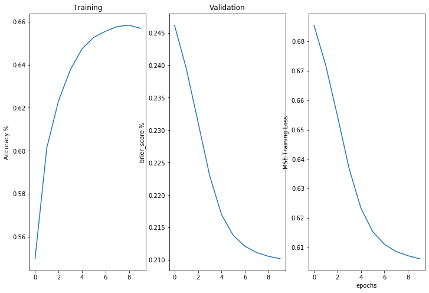

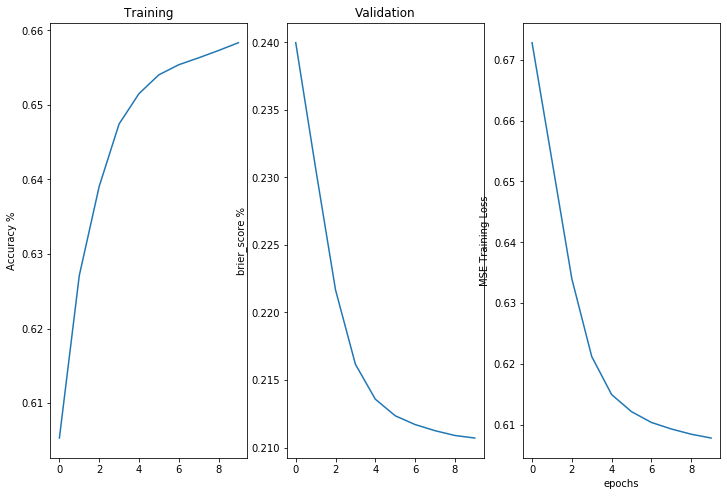

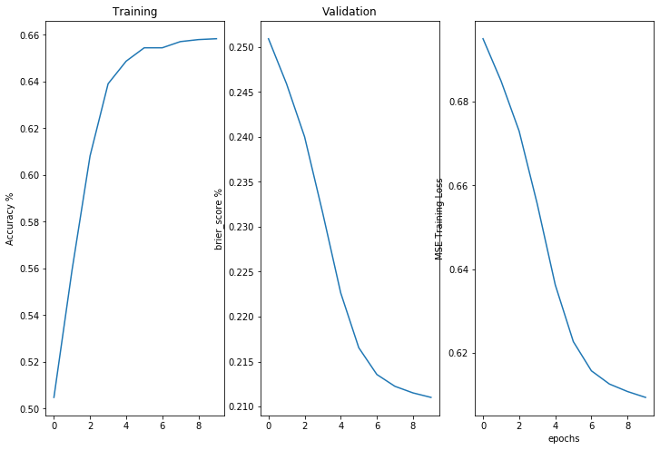

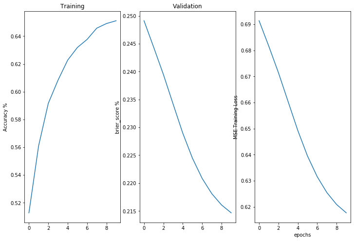

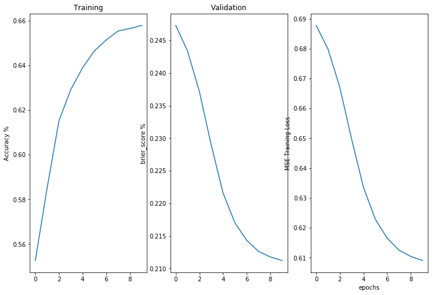

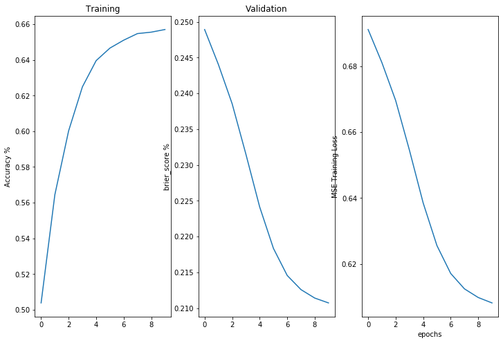

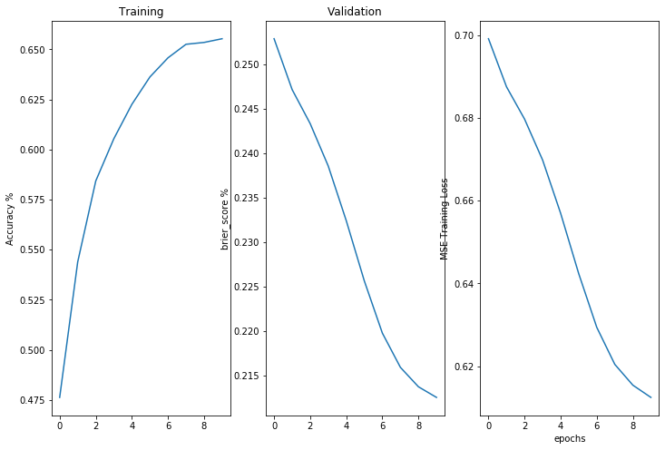

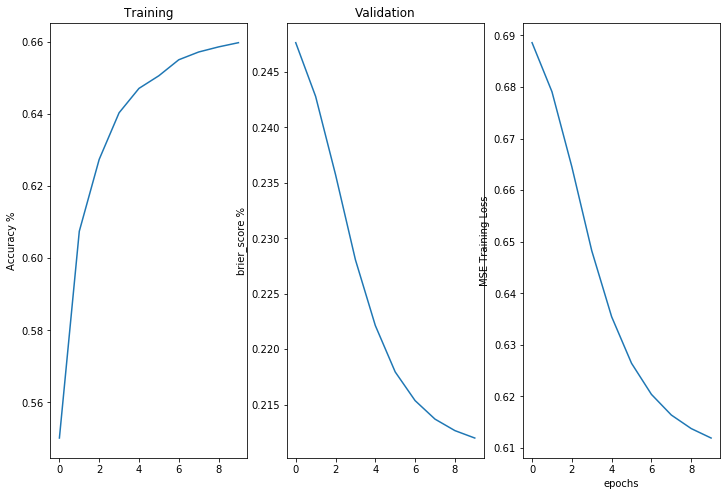

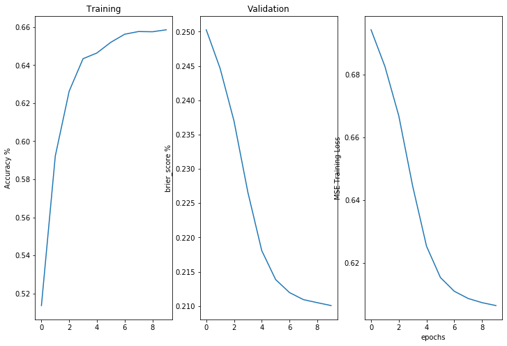

```python
model2 = cross_validation_wide_deep(X_train, X_test, y_train, y_test, cross_columns2)
```